# Assignment 3: Neural Volume Rendering and Surface Rendering

Author: [Mukai (Tom Notch) Yu](https://tomnotch.com)

Email: mukaiy@andrew.cmu.edu

## A. Neural Volume Rendering (80 points)

### 0. Transmittance Calculation (10 points)

According to **slide L09_Volume_Rendering Page 42**: \begin{align*} T(x, y) & = e^{-\sigma \|x - y\|} \\ T(x, y) & = T(x, z) \cdot T(z, y) \end{align*} Thus everything's solved. \begin{align*} T(y_1, y_2) & = e^{-\sigma_1 \| y_1 - y_2 \|} = e^{-1 \times 2} = e^{-2} \\ T(y_2, y_4) & = e^{-\sigma_2 \| y_2 - y_3 \|} \cdot e^{-\sigma_3 \| y_3 - y_4 \|} = e^{-0.5 \times 1} \cdot e^{-10 \times 3} = e^{-30.5} \\ T(x, y_4) & = T(x, y_1) \cdot T(y_1, y_2) \cdot T(y_2, y_4) = 1 \times e^{-2} \times e^{-30.5} = e^{-32.5} \\ T(x, y_3) & = T(x, y_1) \cdot T(y_1, y_2) \cdot T(y_2, y_3) = 1 \times e^{-2} \times e^{-0.5} = e^{-2.5} \end{align*} Probably hitting an object between $y_3$ an $y_4$.

### 1. Differentiable Volume Rendering

#### 1.3. Ray sampling (5 points)

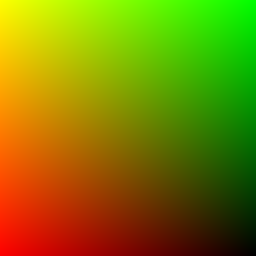

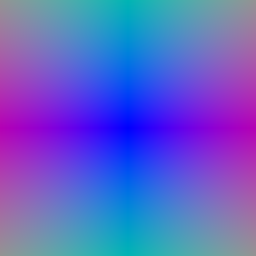

#### 1.4. Point sampling (5 points)

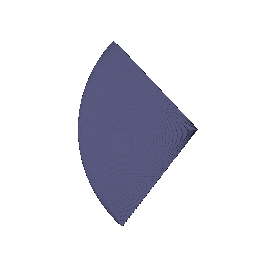

#### 1.5. Volume rendering (20 points)

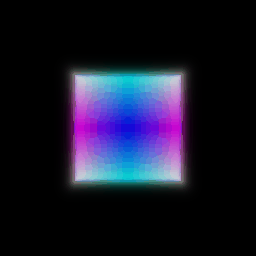

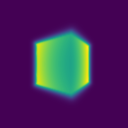

### 2. Optimizing a basic implicit volume

#### 2.1. Random ray sampling (5 points)

```
def get_random_pixels_from_image(n_pixels, image_size, camera):
    xy_grid = get_pixels_from_image(image_size, camera)

    # TODO (Q2.1): Random subsampling of pixel coordinaters
    xy_grid_flat = xy_grid.reshape(-1, 2)
    indices = torch.randperm(xy_grid_flat.shape[0])
    xy_grid_sub = xy_grid_flat[indices]

    # Return
    return xy_grid_sub.reshape(-1, 2)[:n_pixels]
```

#### 2.2. Loss and training (5 points)

Box center: (0.2502334713935852, 0.25057852268218994, -0.0004771414096467197)

Box side lengths: (2.005112409591675, 1.5035951137542725, 1.503396987915039)

#### 2.3. Visualization

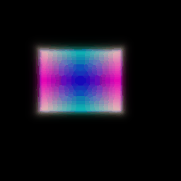

I see no difference.

### 3. Optimizing a Neural Radiance Field (NeRF) (20 points)

[figure not shown]

### 4. NeRF Extras

#### 4.1 View Dependence (10 points)

We had to incorporate noise in our training? which is not mentioned in class? Looks like some hacky solution, heuristics go over theory again? ...

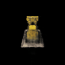

No difference when the resolution is low.

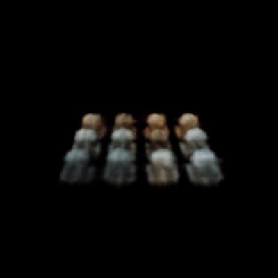

OK, I must say there is something in NeRF.

## B. Neural Surface Rendering (50 points)

### 5. Sphere Tracing (10 points)

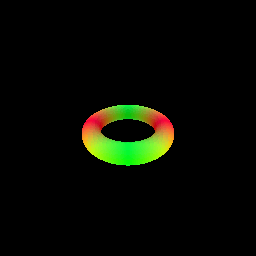

### 6. Optimizing a Neural SDF (15 points)

[figure not shown]

[figure not shown]

### 7. VolSDF (15 points)

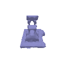

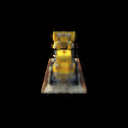

$\alpha = 10, \beta = 0.05$

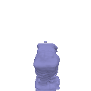

[figure not shown]

$\alpha = 10, \beta = 0.5$

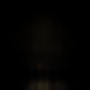

$\alpha = 10, \beta = 1$

Well, $\beta$ controls the sharpness of density change across the boundary of an object when the underlying implicit geometry function is SDF.

### 8. Neural Surface Extras

#### 8.2 Fewer Training Views (10 points)

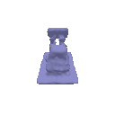

[figure not shown]

Neural Surface with 20% training views.

[figure not shown]

NeRF with 20]% training views.

Of course they are more "hollow".